# Relatório do Estudo de Caso: Estudantes de Biologia

### Fernando Dias, Liliana Cioci Ferreira e Thais Estruc.

### 2017-10-16

## 1 – Introdução/Objetivos

Os temas relacionados à área de conhecimento de Biologia estão cada vez mais inseridos nos meios de comunicação, jornais, revistas e internet, cabendo ao professor à responsabilidade de apresentar esses assuntos de maneira a possibilitar que o aluno associe a realidade do desenvolvimento científico atual com os conceitos básicos do pensamento biológico. Desta forma, o avanço científico na área de Biologia, o fácil acesso ao conteúdo e a atual metodologia de ensino, pautado na memorização de denominações e conceitos, tem elevado a grande desmotivação e desinteresse dos alunos pela Biologia na escola.

A desmotivação em aprender Biologia, segundo Teixeira & Vale (2001), está associada à especificidade e abstração do conteúdo, dificultando o relacionamento com a realidade do sujeito, que não compreende o porquê de aprender tal conteúdo. Para Krasilchik (2008), muitos dos estudantes memorizam informações, muitas vezes sem compreender a conexão de um fato ao outro, apenas para atender as exigências escolares. Para Moura & Vale (2003), os professores devem enfatizar as atividades que favoreça a espontaneidade do aluno e seus conceitos cotidianos, permitindo que o aluno construa noções necessárias para a compreensão da ciência. Contudo, é necessário considerar a diversidade presente nas diferentes salas de aula e nas diferentes escolas.

Dentro deste contexto, o presente estudo visa traçar o perfil dos alunos e identificar os fatores que impactam o gosto pelo estudo de Biologia entre os alunos da rede pública e privada do Estado do Rio de Janeiro. Com base nesses dados, visa-se propor ações de incentivo para o ensino de Biologia para o Ministério da Educação.

## 2 – Metodologia

Foram entrevistados 1.336 alunos da rede pública e privada do estado do Rio de Janeiro, para avaliar o grau de interesse pela Biologia numa escala de 0 a 10. Essas informações foram inseridas em um banco de dados utilizando um programa de planilha eletrônica.

Além disso, foi traçado um perfil dos alunos, baseado no tipo de escola, turno, sexo, idade e raça. Todos os parâmetros e estatísticas foram avaliados no Software R-Project, após a importação do banco de dados, e analisados visando identificar os fatores que impactam no interesse pelo estudo de Biologia.

No mesmo banco de dados haviam 49 alunos do estado de São Paulo, esses alunos não eram objetos de estudo por isso foram removidos antes da análise estatística. Essa ação foi realizada na fase de análise crítica de dados, utilizando o próprio Software R-Project.

## 3 - Resultados encontrados

### Perfil do Aluno

Baseado na análise dos dados foi possível estabelecer o perfil dos estudantes do ensino médio do RJ. As variáveis estudadas para a montagem desse perfil foram: 1 - tipo de escola (pública ou particular), 2 - classe ou turno, 3 - sexo, 4 - idade e 5 - raça/cor.

As duas primeiras variáveis referem-se à distribuição dos alunos por escola e por turno. A observação da primeira distribuição informa que a maioria dos alunos estuda em escolas públicas (69,84%), o restante em escolas privadas (30,16%) (Gráfico 1). A análise da segunda distribuição mostra que a maior parte dos estudantes (64,15%) é da manhã, 24,1% deles da tarde e o restante é da noite e do turno integral, 6,59% e 5,16% respectivamente (Gráfico 2).

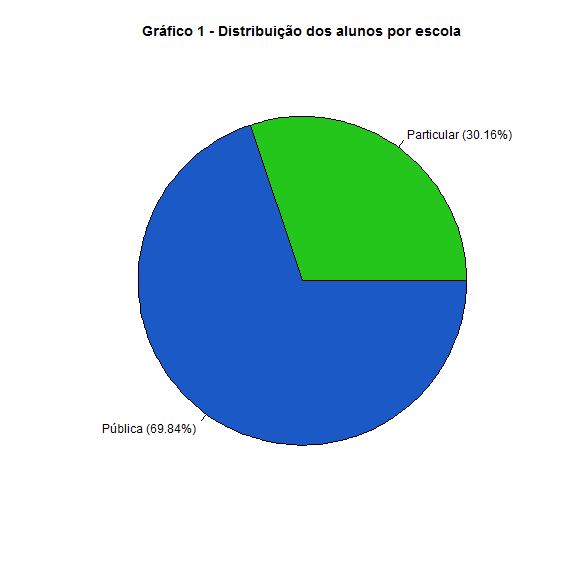

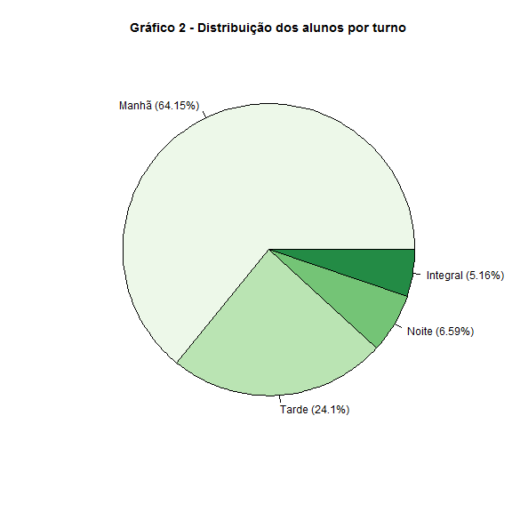

Comparou-se ainda a distribuição dos alunos por turno e por tipo de escola (Gráfico 3). Nos turnos da manhã e da tarde há mais alunos nas escolas públicas. No turno da noite a quantidade de alunos nos dois tipos de escolas é praticamente a mesma. Já no turno integral há mais alunos nas escolas particulares.

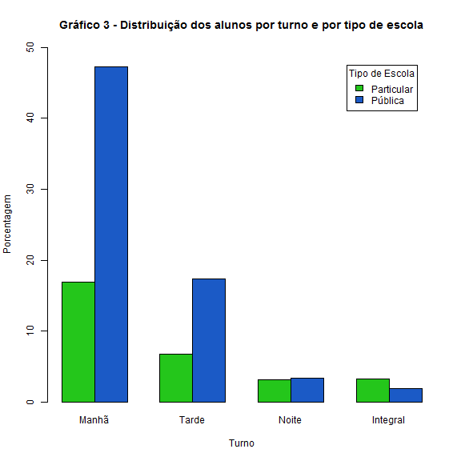

As outras três variáveis referem-se aos alunos. Em relação ao sexo, há praticamente a mesma quantidade de alunos homens que mulheres. São 50,37% do sexo masculino contra 49,48% do sexo feminino (Gráfico 4). Dois alunos (ou 0,15%) não tiveram o sexo identificado, isso pode ter ocorrido por um erro na preparação do banco de dados.

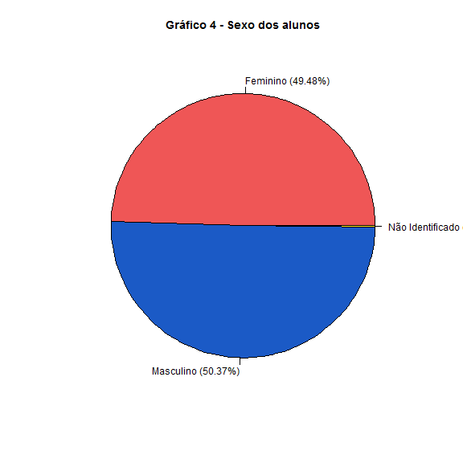

Relacionou-se a variável sexo pela cor dos alunos (Gráfico 5). É possível observar que a maior parte dos alunos é da cor branca, a outra parcela é composta por negros, amarelos, indígenas e outros. A raça “outra” é composta por alunos que não se encaixam em nenhum dos grupos. Não existem diferenças significativas entre os sexos quando relacionados com a cor.

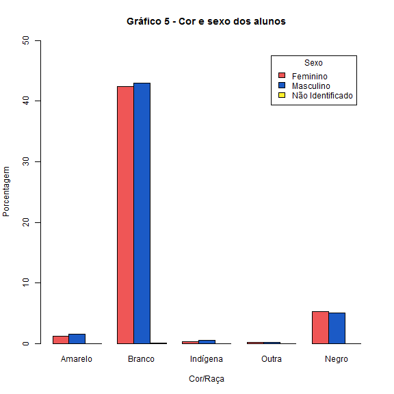

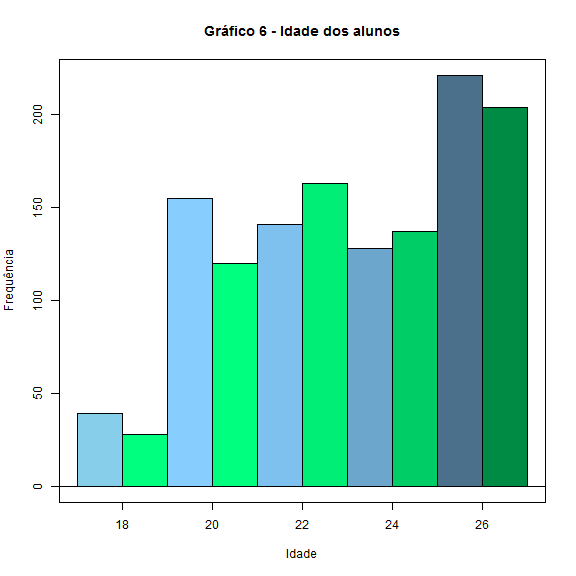

As últimas análises realizadas para estabelecer o perfil do aluno foram relacionar a idade, sexo e cor por turno. Em relação às idades a melhor maneira de compara-las é observando a mediana, representada pela linha preta lateral no boxplot. Nos turnos da manhã, tarde e integral a mediana é de 24 anos. A distribuição das idades é menor no turno integral, isso se deve ao menor número de alunos. No turno da noite a mediana é de 23 anos (Gráficos 7).

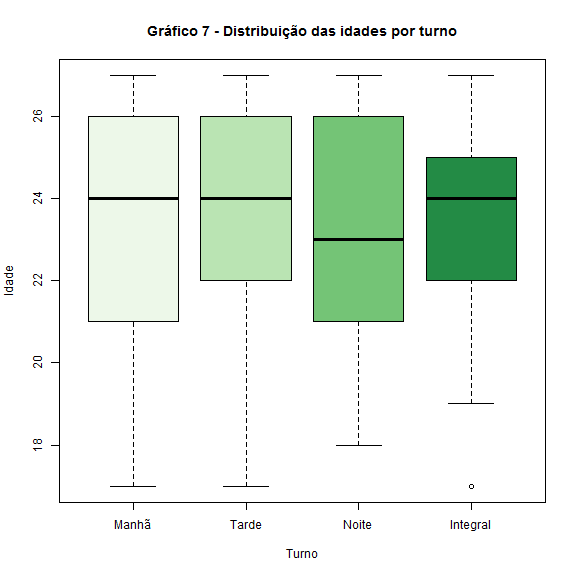

Em relação ao sexo há mais mulheres nos turnos da manhã e da tarde em relação aos homens. Os turnos da noite e integral possuem mais homens que mulheres (Gráfico 8).

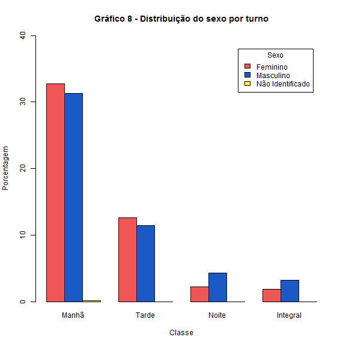

A distribuição da cor dos alunos é semelhante entre os turnos (Gráfico 9).

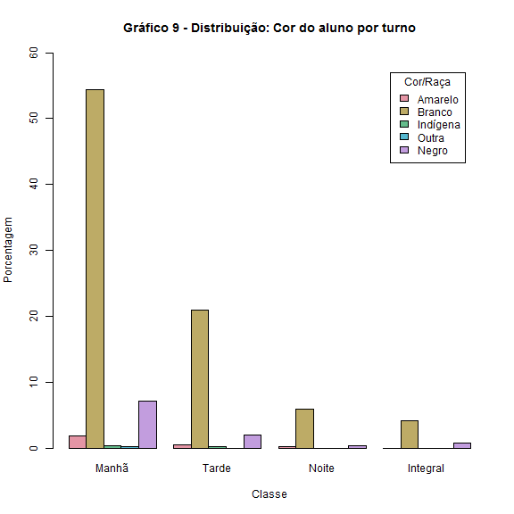

### Fatores que influenciam o gosto por biologia

A partir de relações entre a variável “Gosta.de.Biologia” e as demais variáveis do banco de dados foi possível determinar fatores que influenciam o gosto por Biologia.

Foi feita análise através do gráfico boxplot do gosto pela biologia por cor, sexo, tipo de escola e turma. Ao comparar o gosto pela Biologia pela cor (Gráfico 10), verificou-se que os alunos da cor branca e negra apresentam uma mediana menor do que os demais alunos. Além disso, eles têm uma variabilidade dos conjuntos menores do que as demais variáveis.

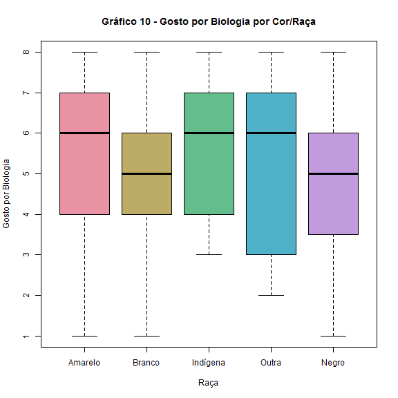

Ao comparar o gosto pela Biologia com o sexo (Gráfico 11), os alunos do sexo masculino possuem uma mediana ligeiramente maior que os do sexo feminino, estando esta na linha do terceiro quartil.

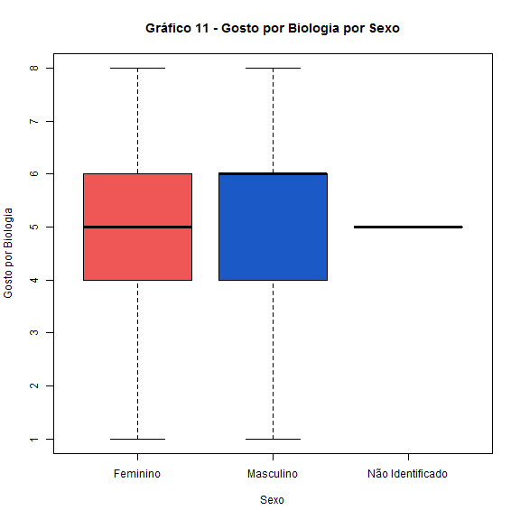

Na análise do gosto pela Biologia pelo tipo de escola (Gráfico 12), verifica-se que a mediana dos alunos de escola pública é maior do que os da escola particular, estando à mediana da escola pública na linha do terceiro quartil.

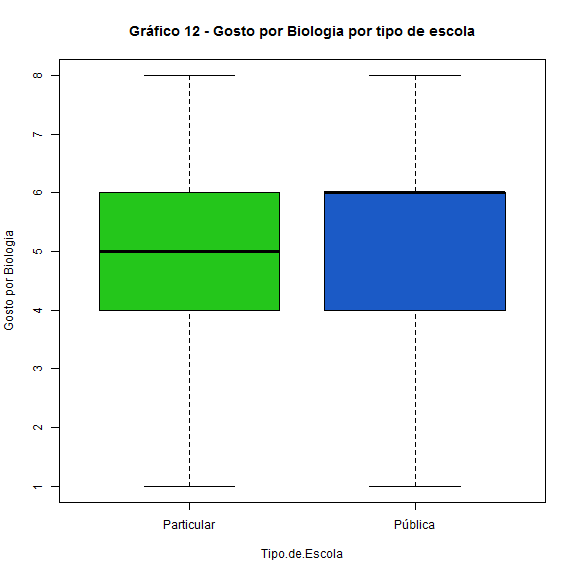

Quanto a análise do gosto pela biologia por turno, foi observado que os alunos da manhã, noite e integral possuem a mesma distribuição. No turno da tarde, a mediana é maior.

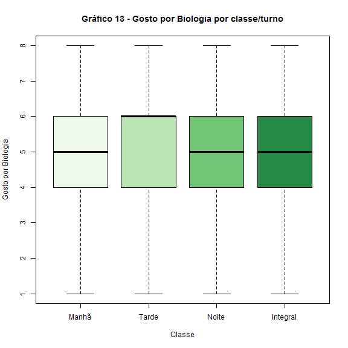

Ao avaliar a matriz de correlação entre o gostar de Biologia e a idade do aluno verificou-se que há pouca correlação entre as variáveis (r=-0.009782648) (Tabela).

Ao testar o grau de correlação entre gostar de Biologia e a idade com o sexo (Gráfico14) e com o tipo de escola (Gráfico 15) verificou-se que não há correlação entre elas.

```
[1] "Gráfico 14 - Relação da idade e o gosto por biologia, considerando o sexo"
```

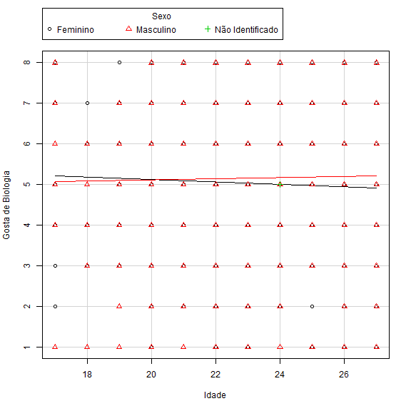

```
[1] "Gráfico 15 - Relação entre a idade e o gosto por biologia, considerando o tipo de escola"
```

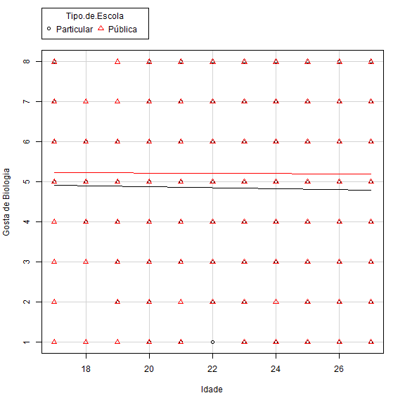

No entanto, ao testar o mesmo grau de correlação com a raça (Gráfico 16), foi observado que os alunos que declararam ser de outra raça, que quanto maior a idade maior é o gosto pela Biologia.

```
[1] "Gráfico 16 - Relação entre a idade e o gosto por biologia, considerando a cor/raça"
```

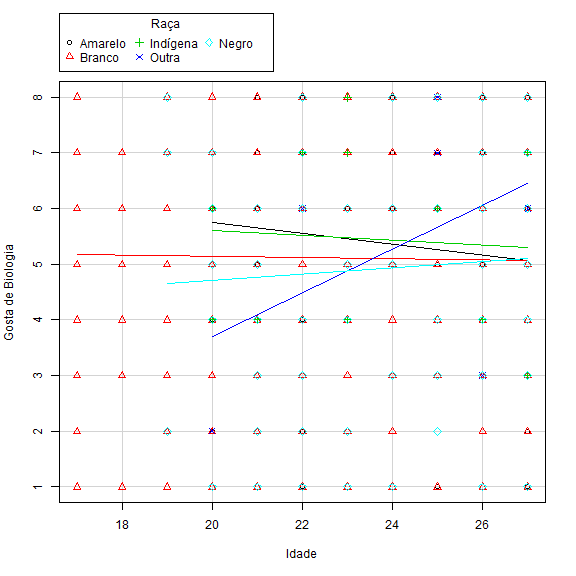

A última relação feita foi entre a quantidade de alunos na sala e o gosto por biologia. Para isso utilizou-se a mediana do gosto dos alunos e a comparou com a quantidade de alunos na sala (Gráfico 17). A mediana foi utilizada no lugar da média por causa da presença de outliers, que são dados que diferenciam drasticamente de todos os outros.

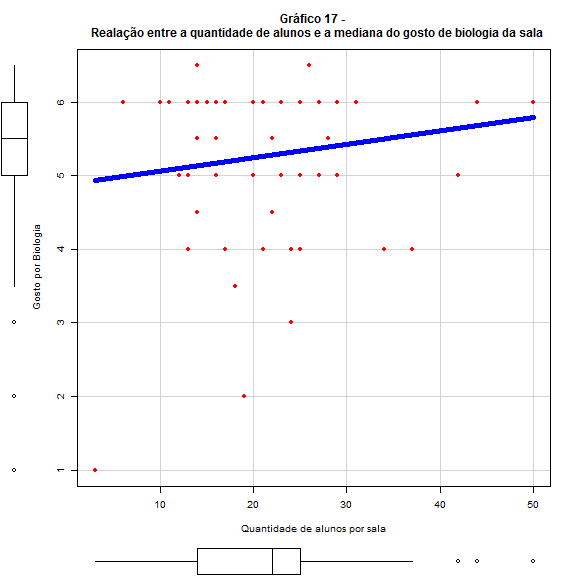

O gráfico dessa relação é um diagrama de dispersão, utilizado para comparar duas variáveis quantitativas. A linha em azul é chamada de linha de quadrados mínimos. Nesse caso ela é uma reta positiva, o que significa um coeficiente de correlação ® positivo; quando a quantidade de alunos na sala aumenta, o gosto por Biologia tende a aumentar também. Contudo, essa correlação não pode ser considerada forte por dois fatores: 1 – a reta é pouco inclinada e 2 – os pontos não estão muito próximos da reta; quanto mais próximos os pontos da linha, maior é a correlação. Os outliers são identificados pelos pontos fora dos boxplots marginais.

## 4 – Discussão

Em relação à quantidade de alunos na sala e o gosto por biologia, observou-se que quanto maior o número de alunos, maior tende ser o gosto dos alunos pela disciplina. Isso pode ocorre também com as outras disciplinas, pois é provável que com o aumento da interação entre os alunos, causada por mais pessoas em um mesmo, mais interessante torna-se a escola.

## 5 – Considerações finais/Recomendação

Considerando os fatores abordados neste estudo, recomenda-se, desde que não atrapalhe o rendimento da aula, a criação e manutenção de turmas grandes, pois isso aumenta a relação entre eles e pode influenciar o gosto dos alunos pela escola como um todo. A adoção de uma metodologia que valorize a interação entre os alunos, com atividades em grupos, pode favorecer o gosto pela disciplina de Biologia, além de melhorar o convívio social entre os alunos.

Além disso, sugerimos ações visando aumentar o interesse dos alunos com atividades interativas e multidisciplinares, como Feiras de Ciência, campeonatos, implantação de laboratórios, e atividades extraclasse.

Contudo, sugerimos um levantamento do interesse dos alunos em outras matérias possibilitando obter uma análise mais profunda não apenas quanto ao estudo de Biologia, mas também os reflexos dos fatores avaliados em outras disciplinas, visando a melhoria na qualidade do ensino.

## 6 – Bibliografia

Aquarela. O que são outliers e como tratá-los em uma análise de dados?. Disponível em: https://aquare.la/o-que-sao-outliers-e-como-trata-los-em-uma-analise-de-dados//. Acesso em: 16 de outubro. 2017.

Wikidot. Variável Explicativa e de Resposta. Disponível em: < [http://mduft.wikidot.com/aula7/>](http://mduft.wikidot.com/aula7/%3E). Acesso em: 16 de outubro. 2017.

KRASILCHIK, M. Prática de Ensino de Biologia. 4ª ed. São Paulo: Editora da Universidade de São Paulo, 2008.

MOURA, G.R.S. & VALE, J.M.F. O ensino de ciências na 5ª e na 6ª séries da escola fundamental. In: NARDI, R. (Org.). Educação em ciências: da pesquisa à pratica docente. 3.ed. São Paulo: Escrituras, 2003. p. 135-143.

TEIXEIRA, P.M.M. & VALE, J.M.F. Ensino de Biologia e cidadania: problemas que envolvem a prática pedagógica de educadores. In: NARDI, Roberto (org.). Educação em Ciências: da pesquisa à prática docente. São Paulo: Escrituras, 2001. p. 23 - 39.